# Project: Hockey Profile of a Rude Player

Author

Giada Brose, Jacob Kasten, Jack Jay

# Lab Introduction

The National Hockey League (NHL) is a North American (Canada & United States) professional sporting league with 32 teams. Teams consist of 23 rostered players (20 playable, 3 reserved), with 6 players (1 Goalie, 2 Defensemen, 3 Offensemen) allowed on the ice at any given moment.

Lots of data is recorded by the NHL, including 1. player demographic data, 2. play-by-play data during games, and 3. penalty data. This lab seeks to analyze NHL data through visualization, interpretation, and simulation. In particular, this lab will be structured as though **YOU** are an NHL Data Analyst, where you will find the player who is penalized the most, then use simulation, shot maps, and data cleaning to create a real NHL profile of this **rude** player!

**Tip**

Data dictionaries are crucial to understanding how the NHL records. Please use the following data dictionary to aid in your NHL Data Analyst journey: [https://cpslo-my.sharepoint.com/:w:/g/personal/jkasten_calpoly_edu/IQAPWSaxak0CSaYkmgiRKu4xAYQB_1qvRaAPBzzcpU9tYhw?e=B8PagT ]

# Pre-Work

#### Loading packages

There are several packages needed in order to use this data. Load them here! Additionally, you will need to install some github packages (hockeyR, sportyR) for this lab. Install them using information from [here] and [here]

```r
library(devtools)
library(hockeyR)
library(tidyverse)
library(sportyR)
library(ggimage)
library(knitr)
library(kableExtra)
library(broom)
```

#### Reading in the data

Additionally, we need to read in our .csv hockey datasets!

```r
nhl_data <- read_csv("NHL Player and General Data.csv")

pbp_data <- read_csv("PBPData.csv")
```

# Cleaning

The multi-billion dollar NHL cannot afford to have clean data, so we need to clean it for them!

#### Question 0: Cleaning play-by-play data

**Important**

The play-by-play dataset is huge, so we’ve cleaned it for you! However, the second dataset of this lab (the NHL Player Data) will be YOUR responsibility to clean :)

### **Question 1: To help simplify and clean the dataset for analysis, complete the following tasks by making a new dataframe from our `nhl_data` dataset. Let’s call it “nhl_clean”:**

#### 1A. Keep only the variables that will be used in the analysis: namefirst, namelast, penaltyminutescareer, penaltyminutes2019season, pimyr, team, teamcode,

#### 1B. Create a “fullname” column combining “namefirst” and “namelast” with a space in-between the names, in addition to that, make sure that the names are properly capitalized.

#### 1C. Drop “namefirst” and “namelast” after creating “fullname”

```r
# Code to do questions 1A-1C
nhl_clean <- nhl_data |>
  select(namefirst, namelast, penaltyminutescareer,
         penaltyminutes2019season, pimyr, team, teamcode, age, height, weight, birthplace, position, captaincode) |>
  mutate(fullname = str_c(namefirst, namelast, sep = " "),
          fullname = str_to_title(fullname)) |>
  select(-namefirst, -namelast)
```

# SIMULATION

In this section, you will be simulating some expected inferential statistics about the variable ‘penaltyminutes2019season’ ::: {.callout-tip} There are lots of ways penalty minutes are dished out in hockey! Typically, we see some variation of 3 core types: - Minors, where players receive a 2 minute penalty and their team is short a player on the ice - Major, where players receive a 5 minute penalty and their team is short a player on the ice - Misconducts, where players receive a 10 minute penalty and their team is **NOT** short a player on the ice

This might help contextualize some of this data! :::

### **Question 2: Find the minimum, maximum, mean, and standard deviation of penaltyminutes2019season. Print these values nicely in a table with kable()**

```r
nhl_clean |>
  select(penaltyminutes2019season) |>
  summarise(max_pim = max(penaltyminutes2019season, na.rm = T),
         min_pim = min(penaltyminutes2019season, na.rm = T),
         mean_pim = mean(penaltyminutes2019season,
                         na.rm = T),
         std_pim = sd(penaltyminutes2019season, na.rm = T)) |>
  kable()
```

| max_pim | min_pim | mean_pim | std_pim |
| --- | --- | --- | --- |
| 32 | 0 | 4.506953 | 5.311763 |

### **Question 3: Simulate a normal distribution using the penaltyminutes2019season variables you found above, using at least n = 1000.**

**Tip**

If you’re not sure how to create this distribution, remind yourself how using the notes from week 8 found below https://manncz.github.io/stat331-calpoly-s26/slides/week-8/w8-simulation.html#/title-slide

```r
sim_pim <- rnorm(n = 1000, mean = 4.507, sd = 5.312)
head(sim_pim, n=5)
```

```
[1] 4.882790 0.519291 5.604884 3.512517 2.435141
```

### **Question 4: Create a histogram of your simulated values to visualize your simulated distribution. Make sure it looks how you would expect a normal distribution to look!**

**Tip**

You are going to have to turn `sim_pim` into a dataframe to use ggplot. Think about how you can use data.frame() to do this!

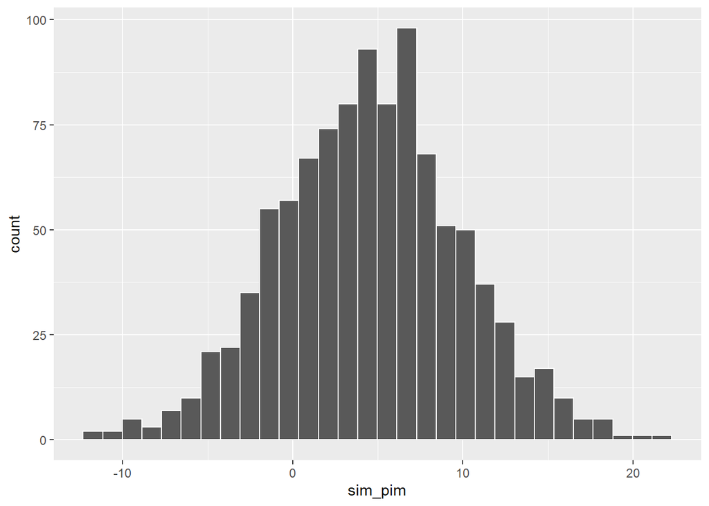

```r
sim_df <- data.frame(sim_pim = sim_pim)

ggplot(sim_df, aes(x = sim_pim)) +
  geom_histogram(color = "white")
```

#### **Question 5. Find the 25th, 50th, and 75th percentiles for penaltyminutes2019.**

```r
twentyfifth <- qnorm(0.25, mean = 4.507, sd = 5.312)
fifty <- qnorm(0.5, mean = 4.507, sd = 5.312)
seventyfifth <- qnorm(0.75, mean = 4.507, sd = 5.312)

twentyfifth
```

```
[1] 0.9241104
```

```r
fifty
```

```
[1] 4.507
```

```r
seventyfifth
```

```
[1] 8.08989
```

#### **Question 6. Create a box-and-whisker plot for penaltyminutes2019 using ggplot2 graphics.**

[figure not shown]

```r
ggplot(nhl_data$penaltyminutes2019, aes(x = sim_pim)) +
  geom_boxplot()
```

### **Question 7: Find what player has the highest penalty minutes in the 2018-2019 season. Additionally, find their team, age, height, weight, birthplace, position, and captain code, and put it in a nicely formatted table with kable(). Call your new created vector ‘rude_player’**

```r
rude_player <- nhl_clean |>
  slice_max(penaltyminutes2019season) |>
  select(fullname, team, age, height, weight, birthplace, position, captaincode) |>
  kable()


kable(
  rude_player,
  caption = "Player with the Highest Penalty Minutes in 2018-2019"
)
```

Player with the Highest Penalty Minutes in 2018-2019

[output not shown]

# Data Analysis

Here, you will be using this data to conduct some classic statistical tests to get a better understanding of hockey penalties. **Maybe this will help you understand hockey penalties more!**

### **Question 8a: Create a linear regression model based on the `penaltyminutes2019season` and `weight`**

Use the tidy() function to make a clean and easy to read data frame output of our model information!

```r
weightlm <- lm(penaltyminutes2019season ~ weight,
             data = nhl_clean)

# Broom output
broom::tidy(weightlm)
```

```
# A tibble: 2 × 5
  term        estimate std.error statistic    p.value
  <chr>          <dbl>     <dbl>     <dbl>      <dbl>
1 (Intercept)  -6.86      2.38       -2.88 0.00412
2 weight        0.0569    0.0119      4.78 0.00000206
```

### **Question 8b: Now, create a graph of this relationship using ggplot & broom packages.**

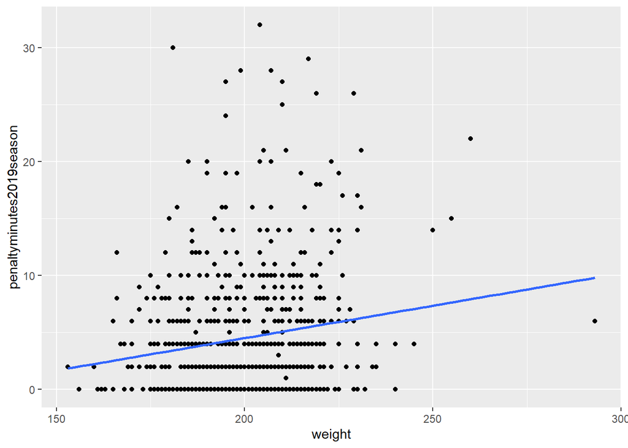

```r
ggplot(nhl_clean, aes(x = weight, y = penaltyminutes2019season)) +
  geom_point() +
  geom_smooth(method = "lm", se = FALSE)
```